# Assignment 2 - Integer Linear Programming

## Problem 1

### Esercizio A

L’algoritmo Brench and Bound al nodo P0 rilassa la condizione di integrità, proponendo quindi i valori delle variabili riportati (5/6,1,0,1), rispettando i vincoli del problema. Al secondo step intende integrare la prima variabile, esegue il Branching su questa ottenendo così due nuove soluzioni: la P1 ottiene un valore più alto della funzione obiettivo rispetto a P2. Si segue quindi la diramazione da P1. Si procede quindi all’applicazione della condizione di integrità sulla variabile x2 ottenendo il valore della funzione obiettivo di P7 maggiore rispetto a quello di P12. Si procede con lo step P9 allo stesso modo, fino al nodo P11 risultante la funzione ottimale. Sono quindi rispettati tutti i vincoli, la funzione obiettivo è massimizzata rispetto alle altre, le variabili sono valori interi. Si nota come ad ogni step dell’algoritmo si computa nuovamente la funzione obiettivo rispetto ai vincoli, e laddove i vincoli non sono rispettati la soluzione diventa “unfeasible”.

Per ogni nodo si ha un limite superiore e inferiore: il primo è dato dalla soluzione della funzione obiettivo di partenza per ogni nodo (quindi laddove non tutte le variabili rispettano la condizione d’integrità), mentre il limite inferiore è dato dalla soluzione della funzione obiettivo nel caso in cui tutte le variabili non intere siano approssimate inferioremente all’intero più prossimo. Chiaramente nel nodo finale i limiti superiore ed inferiore coincidono con la soluzione ottimale.

Seguendo il ragionamento del Brench and Bound, si osservano i limiti inferiore (LL) e superiore (UL) rispetto ai nodi da esso visitati.

$$\textbf{P0} : X_{UL}=(5/6,1,0,1) ; X_{LL}=(0,1,0,1)\\ \textbf{UL} : 16.5 \\ \textbf{LL} : 9$$

$$\textbf{P1} : X_{UL}=(1,4/5,0,4/5) ; X_{LL}=(1,0,0,0)\\ \textbf{UL} : 16.2 \\ \textbf{LL} : 9$$

$$\textbf{P7} : X_{UL}=(1,1,0,1/2) ; X_{LL}=(1,1,0,0)\\ \textbf{UL} : 16 \\ \textbf{LL} : 14$$

$$\textbf{P9} : X_{UL}=(1,1,0,1/2) ; X_{LL}=(1,1,0,0)\\ \textbf{UL} : 16 \\ \textbf{LL} : 14$$

$$\textbf{P11} : X_{UL}=(1,1,0,0) ; X_{LL}=(1,1,0,0)\\ \textbf{UL}=\textbf{LL}=14$$
Come si può notare in questo ultimo caso i limiti coincidono, infatti le variabili sono quelle della soluzione ottimale.

### Esercizio B

Carico il pacchetto lpSolveAPI e imposto un modello con 4 variabili decisionali:

```r
#carico il pacchetto
library(lpSolveAPI)

#creazione di un modello
lp.model<-make.lp(0,4) #4: variabili decisionali

#Si denomina il modello
name.lp(lprec=lp.model,name='Problem_1')
```

```r
#Si tratta di una funzione di massimizzazione
lp.control(lp.model,sense='max')
```

[output not shown]

[output cut: 12 more lines]

[output not shown]

Si definiscono i coefficienti della funzione obiettivo:

```r
set.objfn(lp.model,obj=c(9,5,6,4))
```

Si procede all’inserimento dei vincoli:

```r
add.constraint(lp.model,xt=c(6,3,5,2),type='<=',rhs=10)
add.constraint(lp.model,xt=c(1,1),type='<=',rhs=1,indices=c(3,4))
add.constraint(lp.model,xt=c(-1,1),type='<=',rhs=0,indices=c(1,3))
add.constraint(lp.model,xt=c(-1,1),type='<=',rhs=0,indices=c(2,4))
```

Si specifica che si vuole una soluzione di valori binari assegnati alle variabili:

```r
set.type(lp.model,c(1:4),'binary')
```

Si risolve il problema e si verificano le soluzioni:

```r
solve(lp.model)
```

```
## [1] 0
```

```r
get.variables(lp.model)
```

```
## [1] 1 1 0 0
```

```r
get.objective(lp.model)
```

```
## [1] 14
```

Le soluzioni sono le stesse verificate dal nodo P11 del’albero decisionale.

## Problem 2

### Eserczio A

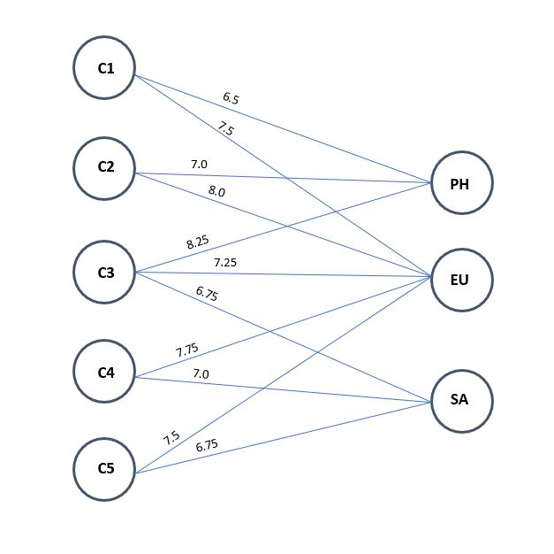

### Esercizio B

Si definiscono le variabili del problema

$$X_{11}= numero \ di \ clienti \ della \ regione \ 1 \ relativi \ a \ Pine \ Hills \\ X_{12}= numero \ di \ clienti \ della \ regione \ 1 \ relativi \ a \ Eustis \\ X_{21}= numero \ di \ clienti \ della \ regione \ 2 \ relativi \ a \ Pine \ Hills \\ X_{22}= numero \ di \ clienti \ della \ regione \ 2 \ relativi \ a \ Eustis \\ X_{31}= numero \ di \ clienti \ della \ regione \ 3 \ relativi \ a \ Pine \ Hills \\ X_{32}= numero \ di \ clienti \ della \ regione \ 3 \ relativi \ a \ Eustis \\ X_{33}= numero \ di \ clienti \ della \ regione \ 3 \ relativi \ a \ Sanford \\ X_{41}= numero \ di \ clienti \ della \ regione \ 4 \ relativi \ a \ Eustis \\ X_{42}= numero \ di \ clienti \ della \ regione \ 4 \ relativi \ a \ Sanford \\ X_{51}= numero \ di \ clienti \ della \ regione \ 5 \ relativi \ a \ Eustis \\ X_{52}= numero \ di \ clienti \ della \ regione \ 5 \ relativi \ a \ Sanford$$

Si definisce il modello come funzione di minimo

$$MIN\ \ \ 6.5X_{11}+7.5X_{12}+7X_{21}+8X_{22}+8.25X_{31}+7.25X_{32}+6.75X_{33}+7.75X_{41}+7X_{42}+7.5X_{51}+6.75X_{52}$$

Si introducono i vincoli relativamente ai clienti

$$X_{11}+X_{12}= 30000 \\ X_{21}+X_{22}= 40000 \\ X_{31}+X_{32}+X_{33}= 25000 \\ X_{41}+X_{42}= 35000 \\ X_{51}+X_{52}= 33000$$

Si introducono i vincoli relativamente alla capacità dei centri di servizio

$$X_{11}+X_{21}+X_{31}<= 60000 \\ X_{12}+X_{22}+X_{32}+X_{41}+X_{51}<= 70000 \\ X_{33}+X_{42}+X_{52}<= 40000$$

Si impone la non negatività delle decision variables

$$X_{11},X_{12},X_{21},X_{22},X_{31},X_{32},X_{33},X_{41},X_{42},X_{51},X_{52}>=0$$

Implementazione del modello e risoluzione

```r
#si imposta un modello con 11 variabili
lp.model2<-make.lp(0,11)

#si tratta di un problema di minimo
lp.control(lp.model2,sense='min')
```

[output not shown]

[output cut: 12 more lines]

[output not shown]

```r
name.lp(lprec=lp.model2,name='Problem_2')
```

Si definisce la funzione obiettivo e si inseriscono i vincoli

```r
#si inseriscono i coefficienti della funzione obiettivo
set.objfn(lp.model2,obj=c(6.5,7.5,7,8,8.25,7.25,6.75,7.75,7,7.5,6.75))

#si inseriscono i vincoli relativi al numero di clienti
add.constraint(lp.model2,xt=c(1,1),type='=',rhs=30000,indices=c(1,2))
add.constraint(lp.model2,xt=c(1,1),type='=',rhs=40000,indices=c(3,4))
add.constraint(lp.model2,xt=c(1,1,1),type='=',rhs=25000,indices=c(5,6,7))
add.constraint(lp.model2,xt=c(1,1),type='=',rhs=35000,indices=c(8,9))
add.constraint(lp.model2,xt=c(1,1),type='=',rhs=33000,indices=c(10,11))

#si inseriscono i vincoli relativi alla capacità dei centri
add.constraint(lp.model2,xt=c(1,1,1),type='<=',rhs=60000,indices=c(1,3,5))
add.constraint(lp.model2,xt=c(1,1,1,1,1),type='<=',rhs=70000,indices=c(2,4,6,8,10))
add.constraint(lp.model2,xt=c(1,1,1),type='<=',rhs=40000,indices=c(7,9,11))

#si inserisce un limite inferiore
set.bounds(lp.model2,lower = rep(0,11))
```

```r
#si definisce che le variabili sono degli interi
set.type(lp.model2,c(1:11),'integer')
```

### Esercizio C

```r
#se solve restituisce il valore 0 il modello è risolto
solve(lp.model2)
```

```
## [1] 0
```

```r
#i seguenti comandi restituiscono le variabili della soluzione
#e il valore della funzione obiettivo
get.variables(lp.model2)
```

```
##  [1] 20000 10000 40000     0     0 25000     0     0 35000 28000  5000
```

```r
get.objective(lp.model2)
```

```
## [1] 1155000
```